# Lab 7: Truncated data

STA 602: Bayesian and Modern Statistics

Oct 31, 2022

**Due:** 12pm, Nov 01, 2022

# Housekeeping

## R/RStudio

You all should have R and RStudio installed on your computers by now. If you do not, first install the latest version of R here: https://cran.rstudio.com (remember to select the right installer for your operating system). Next, install the latest version of RStudio here: https://www.rstudio.com/products/rstudio/download/. Scroll down to the “Installers for Supported Platforms” section and find the right installer for your operating system.

## R Markdown

You are required to use R Markdown to type up this lab report. If you do not already know how to use R markdown, refer to Sakai “Resources/Lab” folder for a very basic R Markdown template as well as a list of resources to help you learn how to use R markdown and LaTex.

## Gradescope

You MUST submit both your .Rmd and .pdf files to Gradescope. Make sure to knit to pdf and not html; ask the TA about knitting to pdf if you cannot figure it out. Be sure to submit under the right assignment entry.

# Getting started

You will need the following R packages. If you do not already have them installed, please do so first using the `install.packages` function.

```r
require(tidyverse)
require(magrittr)
require(bayesplot)
require(loo)
require(readxl)
require(plyr)
require(ggrepel)
library(cowplot)
library(truncnorm)
```

# Introduction

So far we have only worked with the uniform density where the boundaries of the support are known. That is, so far, if $X \sim \textrm{Unif}(a,b)$, then $a$ and $b$ are known. This lab will take you through the process of building a generative model using a conjugate prior for the uniform density on an interval $[0, \theta]$, with some parameter $\theta$. The model we will encounter restricts, or *truncates*, the support of some of the parameters. Using these **truncated distributions**, we will write and implement a Gibbs sampling algorithm to infer the value of the boundary parameter $\theta$ given noisy measurements from a uniform interval.

# Uniform likelihood

Truncated distributions are usually described by a density function accompanied with an indicator function, which modifies the support of the random variable. For instance, a random variable $X$ with a uniform density function on an interval $[0, \theta]$ will have density function:

$$p(x | \theta) = \frac{1}{\theta} \cdot \mathbb{I}[0 < x \leq \theta]$$

Let’s work through the conjuage update for the uniform likelihood to practice working with indicator functions.

## Inference on boundary parameter $\theta$

### Conjugate prior

As a function of $\theta$ alone, the uniform likelihood is proportional to a Pareto density function. If $\theta \sim \textrm{Pareto}(m,k)$, then
$$\pi(\theta | m,k) = \frac{k m^k}{\theta^{k + 1}} \cdot \mathbb{I}[\theta
\geq m],$$

For hyperparameters $m$ and $k$.

The Pareto prior is conjugate for the uniform likelihood, so that the posterior distribution of $\theta$ will also be Pareto. What is the form of this posterior distribution?

### Posterior update

Since we assume an independent sampling mechanism, we can combine the indicator functions from the likelihood densities of the individual $X_i$. The product of indicator functions then becomes a single indicator function operating on a combination of the $X_i$. What does this indicator function look like? What is the posterior support of $\theta$?

$$\begin{aligned}
\pi(\theta | X_1, \dots, X_n) &\propto p(x_1, \dots, x_n | \theta)
\cdot \pi(\theta) \\
& \propto \left(\prod^n_{i=1}\frac{1}{\theta} \mathbb{I}[0 < x_i
\leq \theta] \right) \cdot \frac{1}{\theta^{k + 1}} \mathbb{I}[\theta
\geq m] \\
& \propto \frac{1}{\theta^n} \mathbb{I}[0 < \textrm{all elements
of } \{x_1,\ldots,x_n\} \leq \theta] \cdot \frac{1}{\theta^{k + 1}}
\mathbb{I}[\theta \geq m] \\
& \propto \frac{1}{\theta^n} \mathbb{I}[0 < \max(x_1, \dots, x_n)
\leq \theta] \cdot \frac{1}{\theta^{k + 1}} \mathbb{I}[m \leq \theta] \\
&= \frac{1}{\theta^{k + n + 1}} \cdot \mathbb{I}[0 < \max(x_1,
\dots, x_n, m) \leq \theta] \\
&\propto \text{Pareto}\bigg(\max(x_1, \dots, x_n, m), k + n \bigg)
\end{aligned}$$

# Noisy samples from a disk of unknown radius

Suppose that we obtain “noisy” measurements of points sampled uniformly from a circular area of unknown radius. Our goal will be to infer the radius of the circular area, $R$.

Suppose further that we know in advance:

- The position of the center of the circular area; in this case it is located at the origin, $(0, 0)$.
- At any given angle $\omega$, the points lying along the line from $(0, 0)$ to $(R \cos\omega, R \sin \omega)$ have uniformly distributed *squared* radial magnitudes.
- The noise terms act additively on the squared radius; this is a bit contrived, but it will make the modeling easier, and it implies that at any given angle $\omega$, the noise perturbations will act radially outward or inward.
- The form of the noise distribution; in this case $N(0, \sigma^2)$, with $\sigma^2$ unknown.

The second and third items on the list above tells us that if we observe data drawn uniformly from the surface of a circle with radius $R$, *each point’s squared distance to the center of the circle will be uniformly distributed on $(0, R^2)$ plus some Normal noise $N(0,\sigma^2)$*. Given these facts, let’s think about how we might do inference on $R$.

## 0. Visualize the data generating process

It is often helpful to have a picture of what’s going on when we describe a generative model. Here we can simulate and plot our data, overlaying the true radius $R$ on the sampled points $r_1, \dots, r_n$:

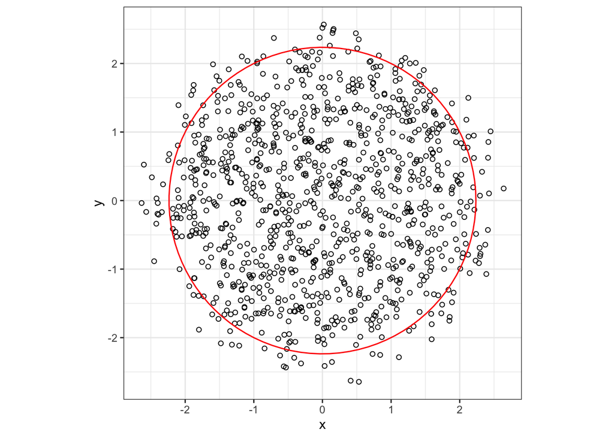

```r
#
n <- 1000
true_Rsquared <- 5
true_sigma <- 1.25
#
u <- runif(n, 0, true_Rsquared)  # de-noised squared distance of each point to (0,0)
r <- u + rnorm(n, sd = true_sigma)  # add normal noise
theta <- runif(n, 0, 2*pi)
#
ggplot2::ggplot() +
  geom_point(data = data.frame(x = sign(r)*sqrt(abs(r))*cos(theta), y = sign(r)*sqrt(abs(r))*sin(theta)),
             aes(x = x, y = y), shape = 1) +
  geom_path(data = data.frame(R = true_Rsquared) %>%
                              plyr::ddply(.(R), function(d){
                                data.frame(x = sqrt(d$R)*cos(seq(0, 2*pi, length.out = 100)),
                                            y = sqrt(d$R)*sin(seq(0, 2*pi, length.out = 100)))
                              }),
                       aes(x = x, y = y), alpha = 1, colour = "red") +
  coord_fixed()
```

## 1. Write down the rest of the generative model

Again, *each point’s squared distance to the center of the circle will be uniformly distributed on $(0, R^2)$ plus some Normal noise $N(0,\sigma^2)$*. Both $R$ and $\sigma^2$ are unknown and we will do inference on them.

Let $r_i$ denote the squared distance of observed data point $i$ to the origin. $r_i$’s are what we can observe.

$r_i$ contains the Normal noise $N(0,\sigma^2)$. Let $u_i$ be the “de-noised” squared distance of the observed data to the origin. Note that we cannot directly observe $u_i$’s.

We assume the following data generating process :
$$\begin{aligned}
r_i | u_i, \sigma^2 &\sim N(u_i, \sigma^2), \\
u_i | R^2 &\overset{iid}\sim U(0, R^2).
\end{aligned}$$
It means that:

- The de-noised squared distance (unobserved) $u_i$ follows a uniform distribution on $(0, R^2)$.
- The observed squared distance $r_i$ is $u_i$ plus some $N(0,\sigma^2)$ noise. Conditional on $u_i$, it follows a normal distribution centered at $u_i$ with variance $\sigma^2$.

Assume the following priors:
$$\begin{aligned}
R^2 | m,k &\sim Pa(m, k) \\
1 / \sigma^2 | \alpha, \beta &\sim Ga(\alpha, \beta)
\end{aligned}$$

Here we have used the conjugate prior, the Pareto distribution, for the uniform likelihood. We have also used the conjugate Gamma prior for the precision parameter.

Unknowns here: $R^2, \sigma^2, u_1,...,u_n$.

## 2. Write down the data likelihood

Write $r = (r_1, \ldots, r_n)$. The generative model implies that the likelihood takes the form

$$\begin{aligned}
L(r ; u, \sigma^2) &= \left(\frac{1}{2 \pi \sigma^2}\right)^{n/2}
\textrm{exp} \left\{-\frac{1}{2 \sigma^2}\sum_{i=1}^n (r_i -
u_i)^2\right\}
\end{aligned}$$

## 3. Write down (and factorize) the joint distribution for all parameters

The joint probability of the observed data $r$ and the unobserved parameters $u, 1/\sigma^2, R^2$ are given as follows:
$$\begin{aligned}
p(r, u, 1/\sigma^2, R^2 | m, k, \alpha, \beta) &= p(r | u,
1/\sigma^2, R^2, m, k) \cdot p(u | R^2) \cdot p(R^2 | m, k) \cdot
p(1/\sigma^2 | \alpha, \beta)
\end{aligned}$$
Here $r$ and $u$ actually denote the joint of $r_1,...,r_n$ and $u_1,...,u_n$, respectively.

## 4. Write down (if possible) full conditional distributions

The full conditionals for $R^2,\sigma^2,u_1,...,u_n$ are given as follows:

$$u_i | r, \sigma^2, R^2 \sim \text{Truncated Normal}\left(r_i, \sigma^2,
0, R^2 \right)$$

$$1 / \sigma^2 | r, u, R^2 \sim Ga\left(n/2 + \alpha,
\frac{1}{2}\sum_{i=1}^n (r_i - u_i)^2 + \beta \right)$$

$$R^2 | u, r, \sigma^2 \sim Pa\left(\max(u_1, \dots, u_n, m), k + n
\right)$$

Here, notation $\text{Truncated Normal}\left(r_i, \sigma^2, 0, R^2 \right)$ means a $N(r_i, \sigma^2)$ truncated on $(0, R^2)$. You can also write a truncated normal by $N_{(0,R^2)}(r_i,\sigma^2)$. To generate random samples from a truncated normal distribution, use `rtruncnorm()` function in `truncnorm` package.

If you are seeing the truncated normal distribution for the first time, take a few minutes to read https://en.wikipedia.org/wiki/Truncated_normal_distribution.

# Sampling and results

Now we are ready to write a Gibbs sampler using truncated full conditional distributions to make inferences about the radius parameter $R$.

```r
# hyper-parameters
m <- 3
k <- 1
alpha <- 5/2
beta <- 5/2

# generate random sample from pareto(m,k)
rpareto <- function(m, k, trunc = NULL){
  p <- m*(1 - runif(1))^(-1/k)
  if(!is.null(trunc)){
    while(p > trunc){
      p <- m*(1 - runif(1))^(-1/k)
    }
  }
  return(p)
}

#
uni_pareto_gibbs <- function(S, r, m, k, alpha, beta, burn_in = min(1000, S / 2), thin = 5){
  # Reparametrize X matrix to squared radius values
  Rsq <- r  # squared distance
  n <- length(Rsq)  # sample size
  R <- rep(1, S)  # to save the S gibbs samples for R^2, also intialized it
  U <- matrix(0, nrow = S, ncol = n)  # to save the S gibbs samples for u_1, ..., u_n
  U[1, ] <- runif(n, 0, R)  # initialize the first sample for u_1, ..., u_n
  sigma <- rep(1, S)  # to save the S gibbs samples for sigma (not sigma2!)
  #
  U_curr <- U[1, ]  # save the updated sample for u_1, ..., u_n
  R_curr <- R[1]  # save the updated sample for R^2
  sigma_curr <- sigma[1]  # save the updated sample for sigma (not sigma2!)
  for(s in 1:S){
    # Sample from full conditional of the inner radius
    R_curr <- rpareto(max(c(U_curr, m)), k + n)
    R[s] <- R_curr
    # Sample from full conditional of U values
    U_curr <- truncnorm::rtruncnorm(n, a = 0, b = R_curr, mean = Rsq, sd = sigma_curr)
    U[s, ] <- U_curr
    # Sample from full conditional of sigma
    sigma_curr <-  ##### [complete this line!] #####
    sigma[s] <- sigma_curr
  }
  return(list(R = R[seq(burn_in, S, by = thin)],
              U = U[seq(burn_in, S, by = thin), ],
              sigma = sigma[seq(burn_in, S, by = thin)]))
}
#
gibbs_samps <- uni_pareto_gibbs(S = 100000, r, m, k, alpha, beta, burn_in=2000)
```

1. Complete the Gibbs sampling step for $\sigma$. Use the full conditional from “part 4” above. Make sure to save as standard deviation $\sigma$ not variance $\sigma^2$.

```r
ggplot2::ggplot() +
  geom_point(data = data.frame(x = sign(r)*sqrt(abs(r))*cos(theta), y = sign(r)*sqrt(abs(r))*sin(theta)),
             aes(x = x, y = y), shape = 1) +
  geom_path(data = data.frame(R = gibbs_samps$R) %>%
                              plyr::ddply(.(R), function(d){
                                data.frame(x = sqrt(d$R)*cos(seq(0, 2*pi, length.out = 100)),
                                            y = sqrt(d$R)*sin(seq(0, 2*pi, length.out = 100)))
                              }),
                       aes(x = x, y = y), alpha = 0.005, colour = "blue") +
  geom_path(data = data.frame(R = true_Rsquared) %>%
                              plyr::ddply(.(R), function(d){
                                data.frame(x = sqrt(d$R)*cos(seq(0, 2*pi, length.out = 100)),
                                            y = sqrt(d$R)*sin(seq(0, 2*pi, length.out = 100)))
                              }),
                       aes(x = x, y = y), alpha = 1, colour = "red") +
  coord_fixed()
```

[output not shown]

2. Make a plot to visualize the marginal posterior density of $R^2$. How does this density compare to the true value of $R^2$?
3. Make a plot to visualize the marginal posterior density of $\sigma^2$. How does this density compare to the true value of $\sigma^2$? Note that the posterior samples are stored as $\sigma$.
4. Make a contour plot to visualize the bivariate posterior density of $R^2$ and $\sigma^2$. Indicate the true value of $(R^2,\sigma^2)$ on the plot. Comment on this bivariate plot.

# Grading

Total 10 points. 10 > Excellent; 8 > Good; 6 > Fair; 0 > Poor; NA if no submission.

# Acknowledgement

This lab was created by [Jordan Bryan](https://scholars.duke.edu/person/jordan.bryan) and [Becky Tang](https://scholars.duke.edu/person/becky.tang).